# Ottava data challenge

Denise Cantoni

2026-11-04

```r
library(ggplot2)
library(dplyr)
library(tibble)

diamonds_df <- ggplot2::diamonds |>
  select(-x,-y, -z)
diamonds_df
```

```
## # A tibble: 53,940 × 7
##    carat cut       color clarity depth table price
##    <dbl> <ord>     <ord> <ord>   <dbl> <dbl> <int>
##  1  0.23 Ideal     E     SI2      61.5    55   326
##  2  0.21 Premium   E     SI1      59.8    61   326
##  3  0.23 Good      E     VS1      56.9    65   327
##  4  0.29 Premium   I     VS2      62.4    58   334
##  5  0.31 Good      J     SI2      63.3    58   335
##  6  0.24 Very Good J     VVS2     62.8    57   336
##  7  0.24 Very Good I     VVS1     62.3    57   336
##  8  0.26 Very Good H     SI1      61.9    55   337
##  9  0.22 Fair      E     VS2      65.1    61   337
## 10  0.23 Very Good H     VS1      59.4    61   338
## # ℹ 53,930 more rows
```

## PRIMA DOMANDA

First of all, observe that low quality diamonds (with respect to cut, color and clarity) are more expensive.

- Il taglio migliore è Ideale, il peggiore è Discreto
- Il colore migliore è D, il peggiore è J.
- La chiarezza migliore è IF, la peggiore è I1

```r
plot_cut <- diamonds_df |>
  ggplot(aes(x = cut, y = price)) +
  geom_boxplot( outlier.alpha = 0.1) +
  labs(title = "Costo dei diamanti in base al loro taglio") +
  scale_y_log10() +
  theme_minimal()
```

```r
plot_color <- diamonds_df |>
  ggplot(aes(x = color, y = price)) +
  geom_boxplot( outlier.alpha = 0.1) +
  labs(title = "Costo dei diamanti in base al loro colore") +
  scale_y_log10() +
  theme_minimal()
```

```r
plot_clarity <- diamonds_df |>
  ggplot(aes(x = clarity, y = price)) +
  geom_boxplot( outlier.alpha = 0.1) +
  labs(title = "Costo dei diamanti in base alla loro chiarezza") +
  scale_y_log10() +
  theme_minimal()
```

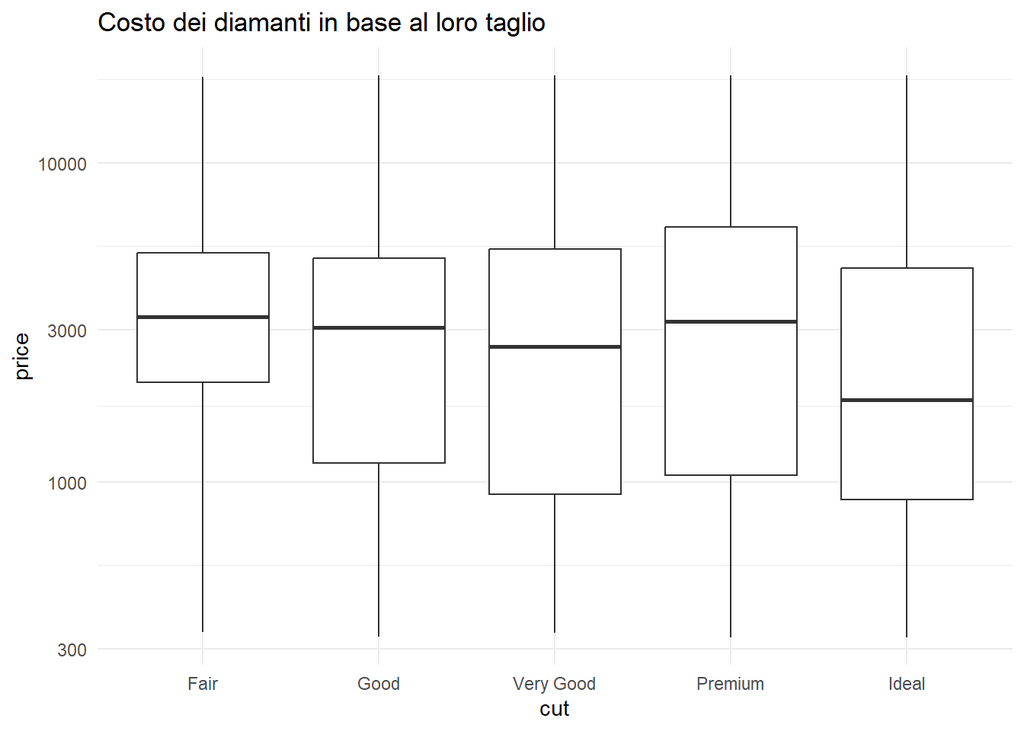

```r
plot_cut
```

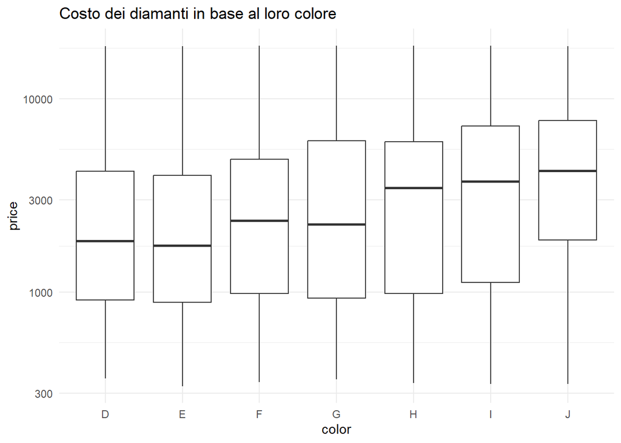

```r
plot_color
```

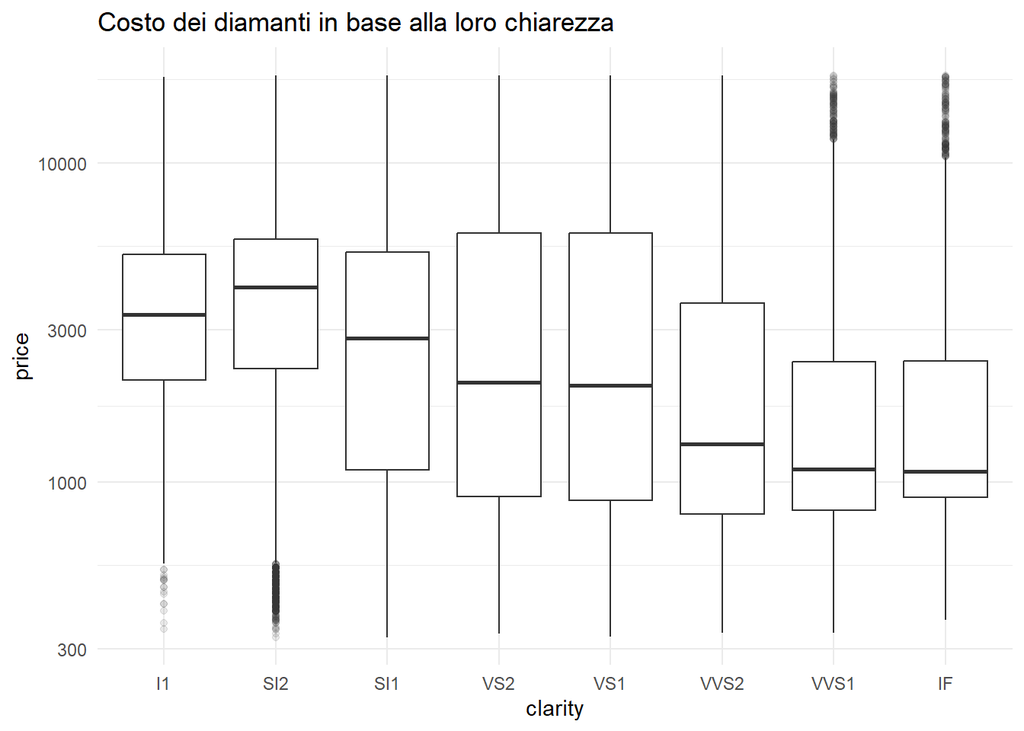

```r
plot_clarity
```

Analizzando i grafici si potrebbe affermazione che i diamanti con caratteristiche di colore, taglio e chiarezza di bassa qualità appaiono più costose rispetto a quelli con caratteristiche migliori. Infatti mediamente le caratteristiche migliori hanno i prezzi più bassi di tutti.

## SECONDA DOMANDA

Using models, find an explanation and solve the apparent paradox.

Il prezzo dei diamanti non è dovuto solo alle loro caratteristiche ma anche alla loro grandezza. I diamanti più pregiati potrebbero essere venduti in dimensioni molto più piccole rispetto a quelli meno rari. Questo abbasserebbe di molto il loro valore reale, perchè a parità di carati varrebbero molto di più. Per questo ora normalizzeremo i dati in base anche alla dimensione (carati) dei diamanti e rivaluteremo i grafici, in modo da avere il prezzo per un carate del diamante.

```r
diamonds_normalizated <- diamonds_df |>
  mutate(PriceNorm = price/carat)
diamonds_normalizated
```

```
## # A tibble: 53,940 × 8
##    carat cut       color clarity depth table price PriceNorm
##    <dbl> <ord>     <ord> <ord>   <dbl> <dbl> <int>     <dbl>
##  1  0.23 Ideal     E     SI2      61.5    55   326     1417.
##  2  0.21 Premium   E     SI1      59.8    61   326     1552.
##  3  0.23 Good      E     VS1      56.9    65   327     1422.
##  4  0.29 Premium   I     VS2      62.4    58   334     1152.
##  5  0.31 Good      J     SI2      63.3    58   335     1081.
##  6  0.24 Very Good J     VVS2     62.8    57   336     1400
##  7  0.24 Very Good I     VVS1     62.3    57   336     1400
##  8  0.26 Very Good H     SI1      61.9    55   337     1296.
##  9  0.22 Fair      E     VS2      65.1    61   337     1532.
## 10  0.23 Very Good H     VS1      59.4    61   338     1470.
## # ℹ 53,930 more rows
```

```r
table_cut <- diamonds_df |>
  mutate(price_norm = price / carat) |>
  group_by(cut) |>
  summarise(
    mean_price = mean(price),
    mean_price_norm = mean(price_norm),
    max_price = max(price),
    max_price_norm = max(price_norm),
    min_price = min(price),
    min_price_norm = min(price_norm)
  )
```

```r
table_color <- diamonds_df |>
  mutate(price_norm = price / carat) |>
  group_by(color) |>
  summarise(
    mean_price = mean(price),
    mean_price_norm = mean(price_norm),
    max_price = max(price),
    max_price_norm = max(price_norm),
    min_price = min(price),
    min_price_norm = min(price_norm)
  )
```

```r
table_clarity <- diamonds_df |>
  mutate(price_norm = price / carat) |>
  group_by(clarity) |>
  summarise(
    mean_price = mean(price),
    mean_price_norm = mean(price_norm),
    max_price = max(price),
    max_price_norm = max(price_norm),
    min_price = min(price),
    min_price_norm = min(price_norm)
  )
```

```r
table_cut
```

```
## # A tibble: 5 × 7
##   cut       mean_price mean_price_norm max_price max_price_norm min_price
##   <ord>          <dbl>           <dbl>     <int>          <dbl>     <int>
## 1 Fair           4359.           3767.     18574         10909.       337
## 2 Good           3929.           3860.     18788         15928        327
## 3 Very Good      3982.           4014.     18818         17829.       336
## 4 Premium        4584.           4223.     18823         17083.       326
## 5 Ideal          3458.           3920.     18806         17078.       326
## # ℹ 1 more variable: min_price_norm <dbl>
```

```r
table_color
```

```
## # A tibble: 7 × 7
##   color mean_price mean_price_norm max_price max_price_norm min_price
##   <ord>      <dbl>           <dbl>     <int>          <dbl>     <int>
## 1 D          3170.           3953.     18693         17829.       357
## 2 E          3077.           3805.     18731         14609.       326
## 3 F          3725.           4135.     18791         13861.       342
## 4 G          3999.           4163.     18818         12461.       354
## 5 H          4487.           4008.     18803         10188.       337
## 6 I          5092.           3996.     18823          9398.       334
## 7 J          5324.           3826.     18710          8647.       335
## # ℹ 1 more variable: min_price_norm <dbl>
```

```r
table_clarity
```

```
## # A tibble: 8 × 7
##   clarity mean_price mean_price_norm max_price max_price_norm min_price
##   <ord>        <dbl>           <dbl>     <int>          <dbl>     <int>
## 1 I1           3924.           2796.     18531          6353.       345
## 2 SI2          5063.           4011.     18804          9912.       326
## 3 SI1          3996.           3849.     18818          9693.       326
## 4 VS2          3925.           4081.     18823         12461.       334
## 5 VS1          3839.           4156.     18795         12403.       327
## 6 VVS2         3284.           4204.     18768         13442.       336
## 7 VVS1         2523.           3851.     18777         14498        336
## 8 IF           2865.           4260.     18806         17829.       369
## # ℹ 1 more variable: min_price_norm <dbl>
```

L’analisi delle tabelle conferma la relazione tra il prezzo dei diamanti e il loro peso(carati) guardando le differenze di prezzo tra quello precedente e quello normalizzato.

Sebbene sia emersa una situazione migliore ci sono dei dati discordanti in quanto, per esempio nel colore, i dati mostrino come il colore peggiore J abbia un prezzo medio minore rispetto al colore migliore D, il quale a sua volta ha un prezzo minore di un colore medio come G.

Come per il colore anche per taglio e chiarezza non abbiamo una situazione molto chiara e definita.

```r
plot_cut_norm <- diamonds_normalizated |>
  ggplot(aes(x = cut, y = PriceNorm)) +
  geom_boxplot( outlier.alpha = 0.1) +
  labs(title = "Costo per un carate dei diamanti in base al loro taglio") +
  scale_y_log10() +
  theme_minimal()

plot_color_norm <- diamonds_normalizated |>
  ggplot(aes(x = color, y = PriceNorm)) +
  geom_boxplot( outlier.alpha = 0.1) +
  labs(title = "Costo per un carate dei diamanti in base alloro colore") +
  scale_y_log10() +
  theme_minimal()

plot_clarity_norm <- diamonds_normalizated |>
  ggplot(aes(x = clarity, y = PriceNorm)) +
  geom_boxplot( outlier.alpha = 0.1) +
  labs(title = "Costo per un carate dei diamanti in base alla loro chiarezza") +
  scale_y_log10() +
  theme_minimal()
```

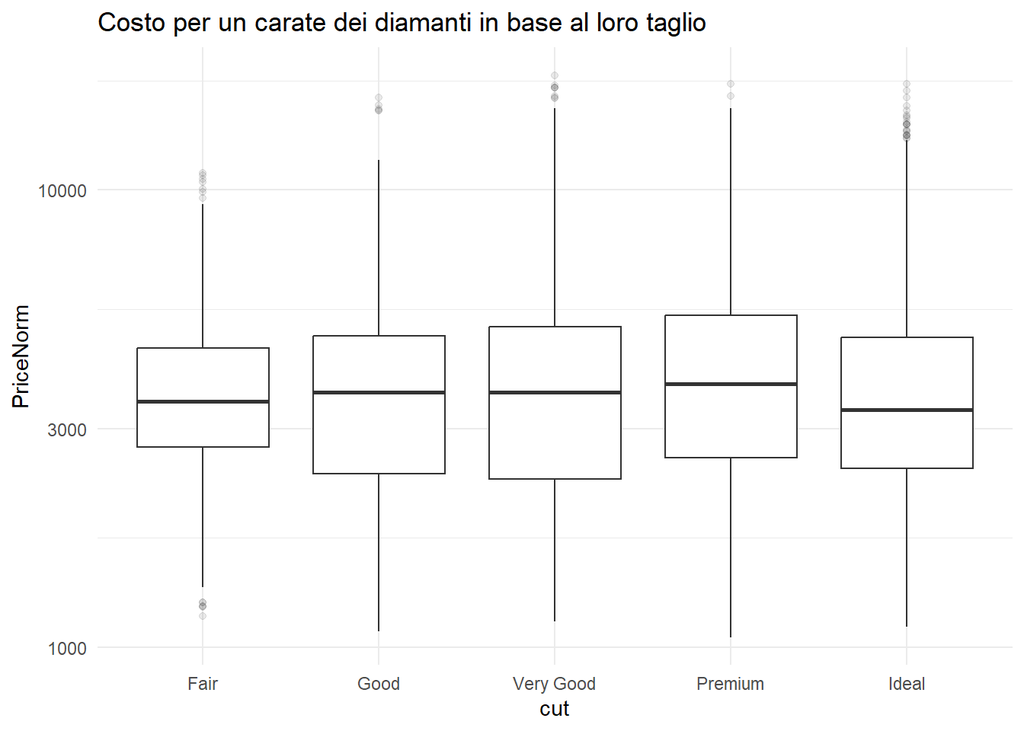

```r
plot_cut_norm
```

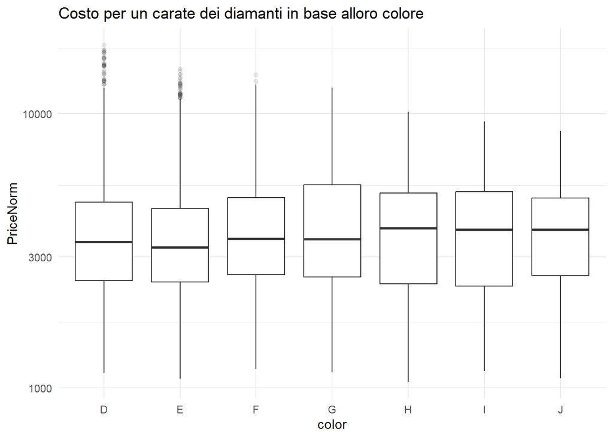

```r
plot_color_norm
```

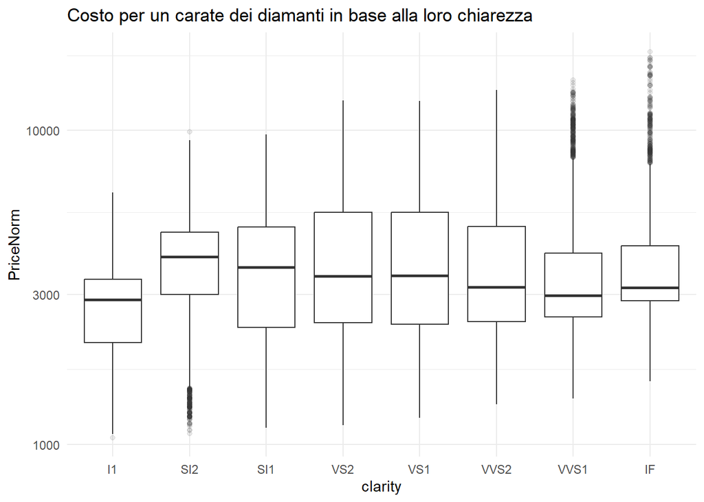

```r
plot_clarity_norm
```

I dati espressi nelle tabelle si possono vedere facilmente nella rappresentazione boxplot.

Probabilmente la normalizzazione eseguita in questo modo non riesce a esprimere la dipendenza del prezzo dalla dimensione/peso del diamante. Per questo creiamo un modello per studiarne il comportamento togliendo i residui(influenza dei carati sul prezzo)

Analizzo il prezzo togliendo la dipendenza tra i carati e le altre variabili di qualità per valutare le singole caratteristiche singolarmente

```r
# Impostazione dei fattori dal peggiore al migliore
diamonds_normalizated <- diamonds_normalizated %>%
  mutate(
    cut       = factor(cut, levels = c("Fair", "Good", "Very Good", "Premium", "Ideal")),
    color     = factor(color, levels = c("J", "I", "H", "G", "F", "E", "D")),
    clarity   = factor(clarity, levels = c("I1", "SI2", "SI1", "VS2", "VS1", "VVS2", "VVS1", "IF"))
  )

# Stima del modello multiplo comprendente anche i carati
modello_multiplo <- lm(log(price) ~ log(carat) + cut + color + clarity, data = diamonds_normalizated)

# Tabella finale dei coefficienti
summary(modello_multiplo)
```

```
##
## Call:
## lm(formula = log(price) ~ log(carat) + cut + color + clarity,
##     data = diamonds_normalizated)
##
## Residuals:
##      Min       1Q   Median       3Q      Max
## -1.01107 -0.08636 -0.00023  0.08341  1.94778
##
## Coefficients:
##              Estimate Std. Error  t value Pr(>|t|)
## (Intercept)  8.457030   0.001168 7242.225  < 2e-16 ***
## log(carat)   1.883718   0.001129 1668.750  < 2e-16 ***
## cut.L        0.120714   0.002354   51.284  < 2e-16 ***
## cut.Q       -0.035115   0.002072  -16.950  < 2e-16 ***
## cut.C        0.013479   0.001799    7.494 6.77e-14 ***
## cut^4       -0.001562   0.001441   -1.084    0.278
## color.L      0.439576   0.002027  216.828  < 2e-16 ***
## color.Q     -0.095623   0.001863  -51.335  < 2e-16 ***
## color.C      0.014783   0.001743    8.481  < 2e-16 ***
## color^4      0.011852   0.001601    7.403 1.35e-13 ***
## color^5      0.002201   0.001513    1.455    0.146
## color^6      0.002391   0.001375    1.739    0.082 .
## clarity.L    0.916832   0.003578  256.274  < 2e-16 ***
## clarity.Q   -0.243038   0.003330  -72.982  < 2e-16 ***
## clarity.C    0.132400   0.002854   46.387  < 2e-16 ***
## clarity^4   -0.066104   0.002283  -28.955  < 2e-16 ***
## clarity^5    0.027418   0.001864   14.711  < 2e-16 ***
## clarity^6   -0.001819   0.001623   -1.120    0.263
## clarity^7    0.033531   0.001432   23.412  < 2e-16 ***
## ---
## Signif. codes:  0 '***' 0.001 '**' 0.01 '*' 0.05 '.' 0.1 ' ' 1
##
## Residual standard error: 0.1338 on 53921 degrees of freedom
## Multiple R-squared:  0.9826, Adjusted R-squared:  0.9826
## F-statistic: 1.693e+05 on 18 and 53921 DF,  p-value: < 2.2e-16
```

L’analisi dei risultati del modello di regressione multipla fornisce una panoramica di come il prezzo dei diamanti dipenda non solo dal peso, ma anche dalle caratteristiche qualitative. Il coefficiente di determinazione multipla ($R^2$) pari a 0,9826 indica che il modello spiega ben il 98,26% della varianza del logaritmo del prezzo.

Il coefficiente associato a `log(carat)`, pari a circa 1,88, mostra un impatto fortissimo e non lineare del peso: un incremento percentuale dei carati si riflette in modo esponenziale sul prezzo finale, a parità di altre condizioni

Al contrario, sebbene anche il taglio, il colore e la chiarezza influenzino il valore della gemma, il loro impatto risulta decisamente meno impattante rispetto a quello dei carati. Per questa ragione, nei passaggi successivi verrà impiegato un modello in grado di depurare il prezzo dalla dipendenza dal peso, così da poter isolare e valutare con precisione l’effetto di ciascuna singola caratteristica qualitativa sul prezzo finale.

```r
# Modello log-log per isolare l'effetto dei carati dal prezzo
modello_carat_effect <- lm(log(price) ~ log(carat), data = diamonds_normalizated)

# Aggiunta dei residui al dataset
diamonds_normalizated <- diamonds_normalizated %>%
  mutate(price_residuals = residuals(modello_carat_effect))

diamonds_normalizated
```

```
## # A tibble: 53,940 × 9
##    carat cut       color clarity depth table price PriceNorm price_residuals
##    <dbl> <ord>     <ord> <ord>   <dbl> <dbl> <int>     <dbl>           <dbl>
##  1  0.23 Ideal     E     SI2      61.5    55   326     1417.         -0.199
##  2  0.21 Premium   E     SI1      59.8    61   326     1552.         -0.0464
##  3  0.23 Good      E     VS1      56.9    65   327     1422.         -0.196
##  4  0.29 Premium   I     VS2      62.4    58   334     1152.         -0.563
##  5  0.31 Good      J     SI2      63.3    58   335     1081.         -0.672
##  6  0.24 Very Good J     VVS2     62.8    57   336     1400          -0.240
##  7  0.24 Very Good I     VVS1     62.3    57   336     1400          -0.240
##  8  0.26 Very Good H     SI1      61.9    55   337     1296.         -0.371
##  9  0.22 Fair      E     VS2      65.1    61   337     1532.         -0.0912
## 10  0.23 Very Good H     VS1      59.4    61   338     1470.         -0.163
## # ℹ 53,930 more rows
```

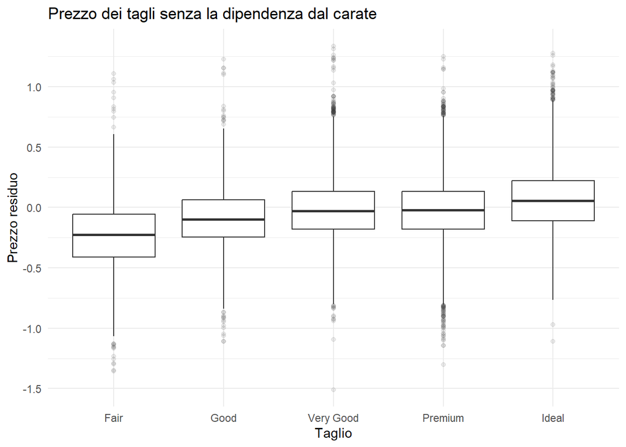

```r
# Boxplot per Cut
plot_cut <- diamonds_normalizated |>
  ggplot(aes(x = cut, y = price_residuals)) +
  geom_boxplot(coef = 2, outlier.alpha = 0.1) +
  labs(title = "Prezzo dei tagli senza la dipendenza dal carate",
       x = "Taglio",
       y = "Prezzo residuo"
  ) +
  theme_minimal() +
  theme(legend.position = "none")

# Boxplot per Color
plot_color <- ggplot(diamonds_normalizated, aes(x = color, y = price_residuals)) +
  geom_boxplot(coef = 2, outlier.alpha = 0.1) +
  labs(title = "Prezzo dei colori senza la dipendenza dal carate",
       x = "Colore",
       y = "Prezzo residuo"
  ) +
  theme_minimal() +
  theme(legend.position = "none")

# Boxplot per Clarity
plot_clarity <- ggplot(diamonds_normalizated, aes(x = clarity, y = price_residuals)) +
  geom_boxplot(coef = 2, outlier.alpha = 0.1) +
  labs(title = "Prezzo delle chiarezze senza la dipendenza dal carate",
       x = "Chiarezza",
       y = "Prezzo Residuo"
  ) +
  theme_minimal() +
  theme(legend.position = "none")

plot_cut
```

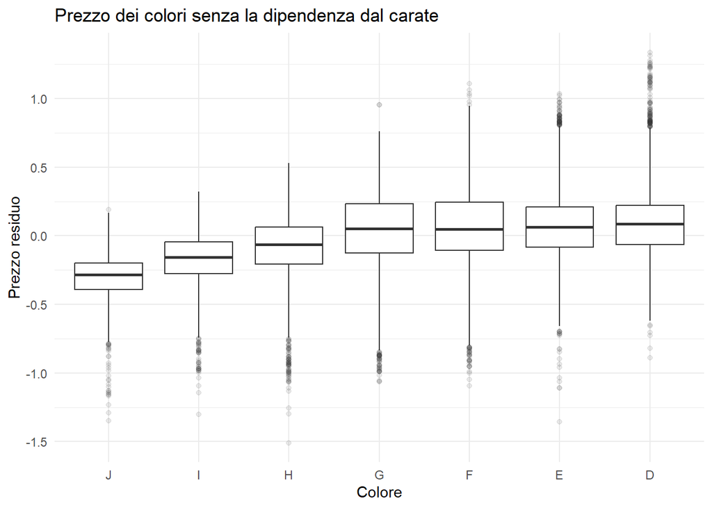

```r
plot_color
```

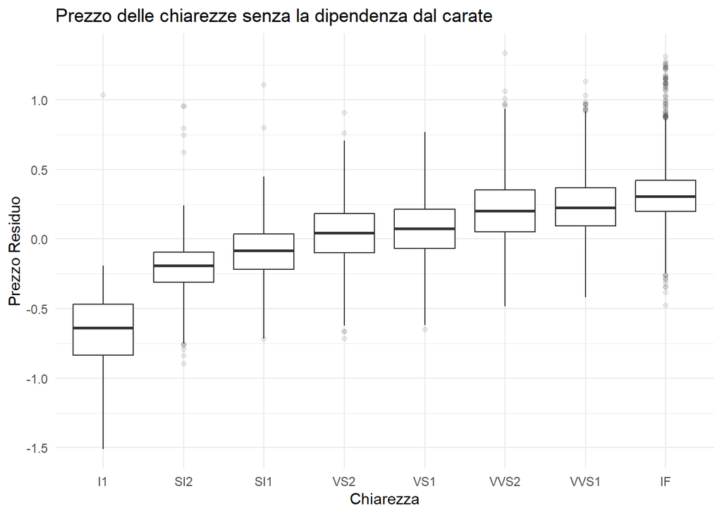

```r
plot_clarity
```

Dall’analisi dei grafici basati sul modello dei residui si capisce come si risolve il paradosso iniziale e la logica del mercato dei diamanti. Usando la regressione per ripulire il prezzo dall’effetto del peso in carati, i grafici del taglio, del colore e della chiarezza mostrano finalmente l’andamento coerente che ci aspetteremmo.

Guardando il taglio, ad esempio, si nota che il valore più basso spetta alla categoria Fair, per poi salire gradualmente fino ad arrivare al taglio Ideal, che ha il prezzo più alto e si trova sopra lo zero. Questo significa che sul mercato un taglio ideale viene premiato con un prezzo superiore rispetto a quello che ci si aspetterebbe solo in base alla sua grandezza, mentre tutti i valori negativi delle altre categorie indicano che il prezzo reale risulta più basso del previsto a causa di una lavorazione meno accurata.

Analogamente nel grafico del colore si nota una situazione simile: la classe J, che è la peggiore, è nella zona negativa sotto lo zero. Man mano che ci si sposta verso le classi superiori e più pregiate, i dati si spostano verso l’alto, premiando le tonalità migliori con mediane positive e valori crescenti.

Lo stesso comportamento si ripete per la chiarezza. Partendo dalla classe I1, che sta nella zona negativa, la situazione migliora fino a raggiungere il picco con la classe IF. Quest’ultima mostra la mediana più alta e un’elevata concentrazione di valori positivi.